# Project Report: Increase Economic Activity & Quality of Life in the South Stockton Promise Zone

#### 8.3 Model 3

```r
# Formulating a model that reflect the relationship between
#Rent to income ratio and population
# 18 to 24.
model3<-lm(Ratio ~ Total.Pop.18.24, data = stkn)
model3
```

```
Call:
lm(formula = Ratio ~ Total.Pop.18.24, data = stkn)

Coefficients:
    (Intercept)  Total.Pop.18.24
      3.224e+01        6.034e-04
```

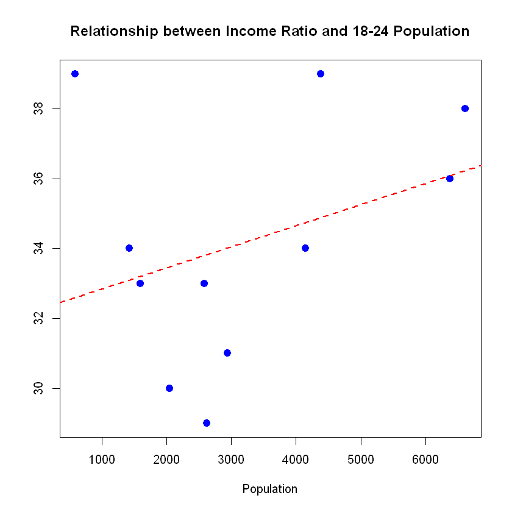

```r
# Let's take a look at plot for model3 to see what inside.
plot(stkn$Ratio ~ stkn$Total.Pop.18.24, col='blue', pch=20, cex=2,
     main="Relationship between Income Ratio and 18-24 Population",
     xlab="Population", ylab="")
abline(model3, col = 'red', lwd = 2, lty="dashed")
```

We could see the lack of relations between the dot and the lines in the model above indicating lack of confident demonstrating the relationship between income to ratio and 18-24 population.

```r
summary(model3)
```

```
Call:
lm(formula = Ratio ~ Total.Pop.18.24, data = stkn)

Residuals:
    Min      1Q  Median      3Q     Max
-4.8268 -1.9119 -0.2065  1.3290  6.4011

Coefficients:
                 Estimate Std. Error t value Pr(>|t|)
(Intercept)     3.224e+01  2.066e+00  15.609 7.98e-08 ***
Total.Pop.18.24 6.034e-04  5.552e-04   1.087    0.305
---
Signif. codes:  0 '***' 0.001 '**' 0.01 '*' 0.05 '.' 0.1 ' ' 1

Residual standard error: 3.456 on 9 degrees of freedom
Multiple R-squared:  0.116,	Adjusted R-squared:  0.01779
F-statistic: 1.181 on 1 and 9 DF,  p-value: 0.3054
```

Take a look at the p value here, it is significant to notice that p value is more than 0.05 which indicates the is not a strong affection between 18- 24 population and rent to income ratio. The Adjusted R-square indicates the percentages of error and the accountability of variances in this model which really insignificant in this case. The line chart indicates that there is not strong linear connection between line and the dots represented data. It seems line the model does not meet the linear assumption significantly.

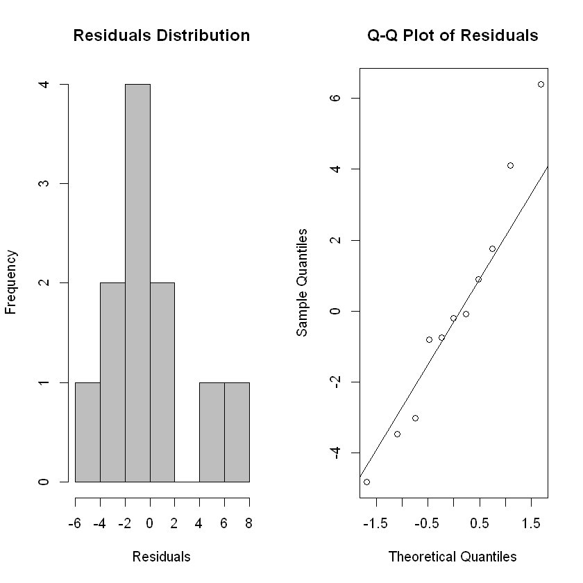

```r
par(mfrow = c(1, 2))
hist(model3$residuals, xlab = "Residuals", col = "gray",
     main = "Residuals Distribution")
qqnorm(model3$residuals, main = "Q-Q Plot of Residuals")
qqline(model3$residuals)
```

The histogram shows residuals that look normally distributed. However, we do plot some outliner of the residual in the histogram. Meanwhile, the closer the residuals hug the diagonal line in the Q-Q plot, the more normal the d istribution, as shown in the following diagrams. Seems like the end of the line goes off track by the end indicating lack of connection.